# Manipulación de Datos en R

06 November, 2021

## Algo de Teoría

## Conceptos clave

**Datos:** medidas u observaciones de interés.

**Unidad muestral:** elemento o individuo de la muestra

**Variable:** característica de interés de un elemento

## Tipos de Variables

- **Numérica** valor es un número
  - **Continua:** la variable puede tomar cualquier valor en un intervalo.
  - **Discreta:** la variable puede tomar una cantidad finita de valores numéricos diferentes.
- **Categórica** valor no es un número
  - **Ordinal:** valores discretos que tienen un orden claro; excelente, bueno, mediocre, malo.
  - **Nominal:** valores discretos sin un orden específico; blanco, negro, rojo, verde, azul.

## Población

**Población:** conjunto de todos los individuos o elementos de interés

**Muestra:** subconjunto de la población, idealmente se espera que la muestra sea representativa de la población.

## Comandos Básicos

## Leer y escribir datos

La carga de datos dependerá del formato en el cual se encuentren. Los formatos más comunes son `.csv`, `.txt` y `.xlsx`. Para cargalos bastará usar los siguientes comandos para cada caso respectivamente.

```r
data_csv <- read.csv("data.csv", header = FALSE, sep = ",")
data_txt <- read.table("data.txt", header = FALSE, sep = " ")
library("xlsx")
data_excel <- read.xlsx("my_excel.xls", header = FALSE)
```

Para escribir cualquier data en un archivo, de acuerdo al formato que estemos empleando dependederá el comando a utilizar.

```r
write.csv(data_csv, sep = ";", file = "mydata.csv", fileEncoding = "utf8")
write.table(data_txt, file = "mydata.txt", sep = " ")
write.xlsx(data_excel, file="mydata.xlsx")
```

## Análisis exploratorio

Luego de leer un archivo, podremos visualizar los primeros o últimos seis registros para darnos una idea de la estructura y variables que posee la data que estamos analizando.

```r
data_covid <- read.csv("data.csv")  #Cargar la data
head(data_covid)                    # 6 primeros
```

```
##        X          DISTRITO METODODX      SEXO EDAD
## 1 563134 SANTIAGO DE SURCO       PR MASCULINO   28
## 2  36568             LINCE      PCR MASCULINO   62
## 3 469676        CARABAYLLO       PR  FEMENINO   35
## 4 104544      PUEBLO LIBRE      PCR  FEMENINO   66
## 5 693522        SAN MIGUEL       PR MASCULINO   30
## 6   4729        CARABAYLLO      PCR MASCULINO   46
```

```r
tail(data_covid)                    # 6 ultimos
```

```
##           X             DISTRITO METODODX      SEXO EDAD
## 995  591485           CARABAYLLO       PR MASCULINO   52
## 996  156658 SAN MARTIN DE PORRES      PCR MASCULINO   45
## 997   67163                COMAS      PCR MASCULINO   36
## 998  582141                  ATE       PR  FEMENINO   38
## 999   42083                  SJL      PCR MASCULINO   46
## 1000 150235    SANTIAGO DE SURCO      PCR MASCULINO   31
```

## Análisis exploratorio (cont.)

Otros comandos de utilidad serán:

```r
dim(data_covid) #dimension
```

```
## [1] 1000    5
```

```r
nrow(data_covid) #numero de filas
```

```
## [1] 1000
```

```r
ncol(data_covid) #numero de filas
```

```
## [1] 5
```

```r
names(data_covid) #nombre de las variables
```

```
## [1] "X"        "DISTRITO" "METODODX" "SEXO"     "EDAD"
```

```r
str(data_covid)   #structura del dataset
```

```
## 'data.frame':    1000 obs. of  5 variables:
##  $ X       : int  563134 36568 469676 104544 693522 4729 475515 804532 485057 564166 ...
##  $ DISTRITO: Factor w/ 43 levels "ANCON","ATE",..: 39 16 5 24 37 5 2 33 9 22 ...
##  $ METODODX: Factor w/ 2 levels "PCR","PR": 2 1 2 1 2 1 2 2 2 2 ...
##  $ SEXO    : Factor w/ 2 levels "FEMENINO","MASCULINO": 2 2 1 1 2 2 1 2 2 2 ...
##  $ EDAD    : int  28 62 35 66 30 46 64 18 52 47 ...
```

## Limpiar los datos

Datos incompletos o vacios pueden alterar el análisis y por ende sesgar los resultados. Por ello siempre será importante realizar la limpieza de nuestro dataset antes de realizar cualquier inferencia.

```r
isna <- is.na(cars) #nos indica los datos faltantes
table(isna)
```

```
## isna
## FALSE
##   100
```

```r
cc <- complete.cases(cars) #nos indica las filas completas (sin NAs)
table(cc)
```

```
## cc
## TRUE
##   50
```

## Unificar el formato

En algunas ocasiones la data registrada no es uniforme.

Por ejemplo si tenemos una columna de distritos, algunos podrían escribir a **San Juan de Lurigancho** como `"SJL"`, `"San Juan de Lurigancho"` o `"SAN JUAN DE LURIGANCHO"`, y todos estos valores hacen referencia al mismo valor.

```
##  [1] "ANCON"                   "ATE"
##  [3] "BARRANCO"                "BRE\xd1A"
##  [5] "CARABAYLLO"              "CHACLACAYO"
##  [7] "CHORRILLOS"              "CIENEGUILLA"
##  [9] "COMAS"                   "EL AGUSTINO"
## [11] "INDEPENDENCIA"           "JESUS MARIA"
## [13] "LA MOLINA"               "LA VICTORIA"
## [15] "LIMA"                    "LINCE"
## [17] "LOS OLIVOS"              "LURIGANCHO"
## [19] "LURIN"                   "MAGDALENA DEL MAR"
## [21] "MIRAFLORES"              "PACHACAMAC"
## [23] "PUCUSANA"                "PUEBLO LIBRE"
## [25] "PUENTE PIEDRA"           "PUNTA HERMOSA"
## [27] "PUNTA NEGRA"             "RIMAC"
## [29] "SAN BARTOLO"             "SAN BORJA"
## [31] "SAN ISIDRO"              "San Juan de Lurigancho"
## [33] "SAN JUAN DE LURIGANCHO"  "SAN JUAN DE MIRAFLORES"
## [35] "SAN LUIS"                "SAN MARTIN DE PORRES"
## [37] "SAN MIGUEL"              "SANTA ANITA"
## [39] "SANTIAGO DE SURCO"       "SJL"
## [41] "SURQUILLO"               "VILLA EL SALVADOR"
## [43] "VILLA MARIA DEL TRIUNFO"
```

## Unificar el formato (cont.)

En este caso si deseamos unificar todas las referencias a San Juan de Lurigancho de una única manera, aplicaremos el comando `replace()`.

```r
data_covid$DISTRITO<-replace(data_covid$DISTRITO,
                             data_covid$DISTRITO == "SJL",
                             "SAN JUAN DE LURIGANCHO")
data_covid$DISTRITO<-replace(data_covid$DISTRITO,
                             data_covid$DISTRITO ==
                              "San Juan de Lurigancho",
                             "SAN JUAN DE LURIGANCHO")
```

Otra manera de hacer lo mismo será:

```r
ids <- which(data_covid$DISTRITO=="SAN JUAN DE LURIGANCHO" |
               data_covid$DISTRITO=="SJL")

for (i in ids) {
  data_covid[i,1] <- "San Juan de Lurigancho"
}
```

## Unificar el formato (cont.)

```r
table(data_covid$DISTRITO)
```

[output not shown]

## Estadística Descriptiva

## Medidas de Tendencia Central

Podemos calcular las diferentes medidas de tendencia central de la siguiente manera:

```r
mean(data_covid$EDAD)  #promedio
```

```
## [1] 43.393
```

```r
median(data_covid$EDAD) #mediana
```

```
## [1] 42
```

```r
sd(data_covid$EDAD)   #desviacion estandar
```

```
## [1] 17.37015
```

```r
min(data_covid$EDAD)  #minimo
```

```
## [1] 0
```

```r
max(data_covid$EDAD)  #maximo
```

```
## [1] 95
```

```r
quantile(data_covid$EDAD) #quantiles
```

```
##   0%  25%  50%  75% 100%
##    0   31   42   56   95
```

Podemos hacer todo lo anterior en un solo comando.

```r
summary(data_covid$EDAD)
```

```
##    Min. 1st Qu.  Median    Mean 3rd Qu.    Max.
##    0.00   31.00   42.00   43.39   56.00   95.00
```

## Medidas de Tendencia Central (cont.)

### ¿Y la moda?

No existe un comando directo para calcular la moda (a no ser que descargues un paquete extra o crees una función para calcularla).

```r
modamia <-function(x){
  tabla<-table(x)
  resultado<-which.max(tabla)
  return (names(resultado))
}
modamia(data_covid$EDA)
```

```
## [1] "35"
```

## Medidas de Tendencia Central (Bonus)

### ¿Sesgo izquierdo o derecho?

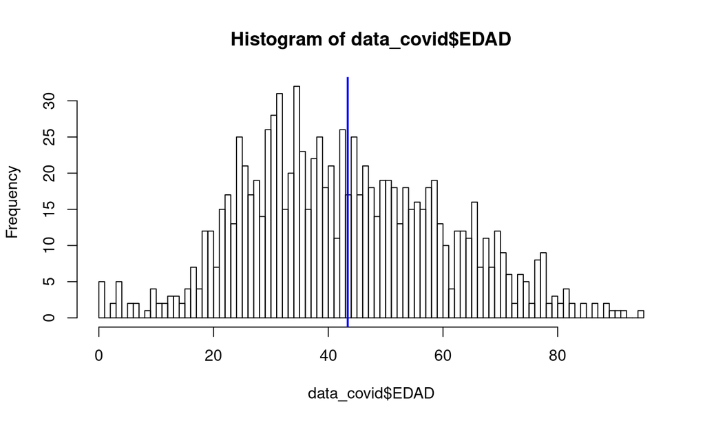

```r
hist(data_covid$EDAD, breaks = 100)
abline(v = mean(data_covid$EDAD), col = "blue", lwd = 2)
```

## Transformación y manipulación de la data

## Dplyr

**dplyr** es un paquete poderoso que nos ayuda a transformar y sintetizar la data de lasa filas y las columnas. Para mayor información consultar el siguiente [enlace](http://cran.rstudio.com/web/packages/dplyr/vignettes/introduction.html)

El paquete contiene funciones para algunas tareas de manipulación de datos conocidas, tales como filtrar filas, seleccionar columnas, añadir nuevas columnas, ordenar filas o resumir la data. Asimismo, posee algunas funciones útiles para tares que incluir el concepto de “divide y combina”.

## ¿Como lo obtengo?

Lo descargo con:

```r
install.packages("dplyr")
```

Lo cargo con:

```r
library(dplyr)
```

## Data: Mammals Sleep

El msleep (mammals sleep) contiene información sobre los tiempos de sueño y el peso de ciertos mamíferos. Está disponible en el repo de “dagdata” en github. Tiene 83 filas con 11 variables.

Se puede descargar desde en formato CSV desde: [here](https://raw.githubusercontent.com/genomicsclass/dagdata/master/inst/extdata/msleep_ggplot2.csv), and then load into R:

```r
url <- "https://raw.githubusercontent.com/genomicsclass/dagdata/master/inst/extdata/msleep_ggplot2.csv"
msleep <- read.csv(url)
head(msleep)
```

```
##                         name      genus  vore        order conservation
## 1                    Cheetah   Acinonyx carni    Carnivora           lc
## 2                 Owl monkey      Aotus  omni     Primates         <NA>
## 3            Mountain beaver Aplodontia herbi     Rodentia           nt
## 4 Greater short-tailed shrew    Blarina  omni Soricomorpha           lc
## 5                        Cow        Bos herbi Artiodactyla domesticated
## 6           Three-toed sloth   Bradypus herbi       Pilosa         <NA>
##   sleep_total sleep_rem sleep_cycle awake brainwt  bodywt
## 1        12.1        NA          NA  11.9      NA  50.000
## 2        17.0       1.8          NA   7.0 0.01550   0.480
## 3        14.4       2.4          NA   9.6      NA   1.350
## 4        14.9       2.3   0.1333333   9.1 0.00029   0.019
## 5         4.0       0.7   0.6666667  20.0 0.42300 600.000
## 6        14.4       2.2   0.7666667   9.6      NA   3.850
```

## Data: Mammals Sleep (cont.)

Las columnas corresponden a las siguientes variables:

| column name | Descripción |
| --- | --- |
| name | Nombre |
| genus | Rango taxonómico |
| vore | Carnivoro, herbivoro o omnivoro? |
| order | Rango taxonómico |
| conservation | Estado de conservación |
| sleep_total | Total de horas de sueño |
| sleep_rem | sueño REM, en horas |
| sleep_cycle | Larco de un ciclo de sueño |
| awake | Horas despierto |
| brainwt | Peso del cerebro, en kilogramos |
| bodywt | Peso del cuerpo, en kilogramos |

## Algunos comandos a tener en cuenta

| dplyr verbs | Description |
| --- | --- |
| `select()` | seleccionar columnas |
| `filter()` | filtrar filas |
| `arrange()` | ordenar filas |
| `mutate()` | crear nuevas columnas |
| `summarise()` | resumir valores |
| `group_by()` | permitir operaciones grupales bajo el concepto de “split-apply-combine” |

## Selecting Columns Using `select()`

Vamos a probar select seleccionando “name” y “sleep_total”

```r
sleepData <- select(msleep, name, sleep_total)
head(sleepData)
```

```
##                         name sleep_total
## 1                    Cheetah        12.1
## 2                 Owl monkey        17.0
## 3            Mountain beaver        14.4
## 4 Greater short-tailed shrew        14.9
## 5                        Cow         4.0
## 6           Three-toed sloth        14.4
```

Para seleccionar todas las columnas *menos* una específica, usa el operador “-” de sustracción (también conocido cono el “negative indexing”)

```r
head(select(msleep, -name))
```

```
##        genus  vore        order conservation sleep_total sleep_rem sleep_cycle
## 1   Acinonyx carni    Carnivora           lc        12.1        NA          NA
## 2      Aotus  omni     Primates         <NA>        17.0       1.8          NA
## 3 Aplodontia herbi     Rodentia           nt        14.4       2.4          NA
## 4    Blarina  omni Soricomorpha           lc        14.9       2.3   0.1333333
## 5        Bos herbi Artiodactyla domesticated         4.0       0.7   0.6666667
## 6   Bradypus herbi       Pilosa         <NA>        14.4       2.2   0.7666667
##   awake brainwt  bodywt
## 1  11.9      NA  50.000
## 2   7.0 0.01550   0.480
## 3   9.6      NA   1.350
## 4   9.1 0.00029   0.019
## 5  20.0 0.42300 600.000
## 6   9.6      NA   3.850
```

Seleccionas un rango de columnas por nombre usando el operador “:”

```r
head(select(msleep, name:order))
```

```
##                         name      genus  vore        order
## 1                    Cheetah   Acinonyx carni    Carnivora
## 2                 Owl monkey      Aotus  omni     Primates
## 3            Mountain beaver Aplodontia herbi     Rodentia
## 4 Greater short-tailed shrew    Blarina  omni Soricomorpha
## 5                        Cow        Bos herbi Artiodactyla
## 6           Three-toed sloth   Bradypus herbi       Pilosa
```

Para seleccionar todas las columnas que empiezan con una cadena de caracteres específica, usamos la función `starts_with()`:

```r
head(select(msleep, starts_with("sl")))
```

```
##   sleep_total sleep_rem sleep_cycle
## 1        12.1        NA          NA
## 2        17.0       1.8          NA
## 3        14.4       2.4          NA
## 4        14.9       2.3   0.1333333
## 5         4.0       0.7   0.6666667
## 6        14.4       2.2   0.7666667
```

Funciones adicionales para la selección de columnas basada en un criterio específico:

1. `ends_with()` = Selecciona columnas que terminen con una cadena de caracteres específica.
2. `contains()` = Selecciona columnas que contengan una cadena de caracteres específica.
3. `matches()` = Selecciona columnas que se adecúen a una expresión regular.
4. `one_of()` = Selecciona columnas que son parte de un grupo de nombres.

## Selecting Rows Using `filter()`

Filtra las filas de mamíferos que duermen en total más de 16 horas.

```r
filter(msleep, sleep_total >= 16)
```

```
##                     name        genus    vore           order conservation
## 1             Owl monkey        Aotus    omni        Primates         <NA>
## 2   Long-nosed armadillo      Dasypus   carni       Cingulata           lc
## 3 North American Opossum    Didelphis    omni Didelphimorphia           lc
## 4          Big brown bat    Eptesicus insecti      Chiroptera           lc
## 5   Thick-tailed opposum   Lutreolina   carni Didelphimorphia           lc
## 6       Little brown bat       Myotis insecti      Chiroptera         <NA>
## 7        Giant armadillo   Priodontes insecti       Cingulata           en
## 8 Arctic ground squirrel Spermophilus   herbi        Rodentia           lc
##   sleep_total sleep_rem sleep_cycle awake brainwt bodywt
## 1        17.0       1.8          NA   7.0 0.01550  0.480
## 2        17.4       3.1   0.3833333   6.6 0.01080  3.500
## 3        18.0       4.9   0.3333333   6.0 0.00630  1.700
## 4        19.7       3.9   0.1166667   4.3 0.00030  0.023
## 5        19.4       6.6          NA   4.6      NA  0.370
## 6        19.9       2.0   0.2000000   4.1 0.00025  0.010
## 7        18.1       6.1          NA   5.9 0.08100 60.000
## 8        16.6        NA          NA   7.4 0.00570  0.920
```

Filtra las filas de mamíferos que duermen en total más de 16 horas *y* tienen un peso corporal de más de 1kg.

```r
filter(msleep, sleep_total >= 16, bodywt >= 1)
```

```
##                     name      genus    vore           order conservation
## 1   Long-nosed armadillo    Dasypus   carni       Cingulata           lc
## 2 North American Opossum  Didelphis    omni Didelphimorphia           lc
## 3        Giant armadillo Priodontes insecti       Cingulata           en
##   sleep_total sleep_rem sleep_cycle awake brainwt bodywt
## 1        17.4       3.1   0.3833333   6.6  0.0108    3.5
## 2        18.0       4.9   0.3333333   6.0  0.0063    1.7
## 3        18.1       6.1          NA   5.9  0.0810   60.0
```

Filtra las filas de mamíferos en el orden taxonómico perisodáctilo y primate.

```r
filter(msleep, order %in% c("Perissodactyla", "Primates"))
```

```
##               name         genus  vore          order conservation sleep_total
## 1       Owl monkey         Aotus  omni       Primates         <NA>        17.0
## 2           Grivet Cercopithecus  omni       Primates           lc        10.0
## 3            Horse         Equus herbi Perissodactyla domesticated         2.9
## 4           Donkey         Equus herbi Perissodactyla domesticated         3.1
## 5     Patas monkey  Erythrocebus  omni       Primates           lc        10.9
## 6           Galago        Galago  omni       Primates         <NA>         9.8
## 7            Human          Homo  omni       Primates         <NA>         8.0
## 8   Mongoose lemur         Lemur herbi       Primates           vu         9.5
## 9          Macaque        Macaca  omni       Primates         <NA>        10.1
## 10      Slow loris     Nyctibeus carni       Primates         <NA>        11.0
## 11      Chimpanzee           Pan  omni       Primates         <NA>         9.7
## 12          Baboon         Papio  omni       Primates         <NA>         9.4
## 13           Potto  Perodicticus  omni       Primates           lc        11.0
## 14 Squirrel monkey       Saimiri  omni       Primates         <NA>         9.6
```

[output cut: 17 more lines]

Se pueden usar los operadores booleanos (e.g. >, <, >=, <=, !=, %in%) para crear pruebas lógicas.

## Pipe Operator: %>%

Antes de proseguir, hay que explicar el pipe operator: %>%. Dplyr importa este operador de otro paquete (magrittr). Con él, puedes “pipe” o conectar la salida (output) de una función con la entrada (input) de otra. Esto permite reducir la cantidad de veces que se requirere anidar funciones( Se leen desde el interior hacia el exterior), la idea de “piping” es que se lean las funciones de izquierda a derecha.

Usemos un ejemplo que ya hemos visto:

```r
head(select(msleep, name, sleep_total))
```

```
##                         name sleep_total
## 1                    Cheetah        12.1
## 2                 Owl monkey        17.0
## 3            Mountain beaver        14.4
## 4 Greater short-tailed shrew        14.9
## 5                        Cow         4.0
## 6           Three-toed sloth        14.4
```

Vamos a “pipear” el data frame msleep a otra función que seleccionará dos columnas (nombre y sleep_total) y luego conectaremos este data frame con la función `head()`, que nos devolverá la cabeza del nuevo data frame.

```r
msleep %>%
    select(name, sleep_total) %>%
    head
```

```
##                         name sleep_total
## 1                    Cheetah        12.1
## 2                 Owl monkey        17.0
## 3            Mountain beaver        14.4
## 4 Greater short-tailed shrew        14.9
## 5                        Cow         4.0
## 6           Three-toed sloth        14.4
```

Se verá la utilidad de este operador cuando se empieza a combinar funciones.

## Back To dplyr Verbs In Action

Utilizaremos el operador “pipe” en el resto del tutorial.

## Arrange Or Re-order Rows Using `arrange()`

Para ordenar (o reordenar) filas bajo una columna en particular, como el orden taxonómico, lita el nombre de la columna cuyas filas requieres reordenar:

```r
msleep %>% arrange(order) %>% head
```

```
##       name     genus  vore        order conservation sleep_total sleep_rem
## 1   Tenrec    Tenrec  omni Afrosoricida         <NA>        15.6       2.3
## 2      Cow       Bos herbi Artiodactyla domesticated         4.0       0.7
## 3 Roe deer Capreolus herbi Artiodactyla           lc         3.0        NA
## 4     Goat     Capri herbi Artiodactyla           lc         5.3       0.6
## 5  Giraffe   Giraffa herbi Artiodactyla           cd         1.9       0.4
## 6    Sheep      Ovis herbi Artiodactyla domesticated         3.8       0.6
##   sleep_cycle awake brainwt  bodywt
## 1          NA   8.4  0.0026   0.900
## 2   0.6666667  20.0  0.4230 600.000
## 3          NA  21.0  0.0982  14.800
## 4          NA  18.7  0.1150  33.500
## 5          NA  22.1      NA 899.995
## 6          NA  20.2  0.1750  55.500
```

Ahora, seleccionamos tres columnas de msleep, ordenaremos las filas por el orden taxonómico, y de ahí ordenaremos nuevamoente por sleep_total. Finalmente, se mostrará la cabeza del data frame.

```r
msleep %>%
    select(name, order, sleep_total) %>%
    arrange(order, sleep_total) %>%
    head
```

```
##       name        order sleep_total
## 1   Tenrec Afrosoricida        15.6
## 2  Giraffe Artiodactyla         1.9
## 3 Roe deer Artiodactyla         3.0
## 4    Sheep Artiodactyla         3.8
## 5      Cow Artiodactyla         4.0
## 6     Goat Artiodactyla         5.3
```

Hacemos lo mismo que el ejemplo de arriba, excepto que acá filtramos las filas por los mamíferos que duermen 16 horas o más en vez de mostrar la cabeza del data frame.

```r
msleep %>%
    select(name, order, sleep_total) %>%
    arrange(order, sleep_total) %>%
    filter(sleep_total >= 16)
```

```
##                     name           order sleep_total
## 1          Big brown bat      Chiroptera        19.7
## 2       Little brown bat      Chiroptera        19.9
## 3   Long-nosed armadillo       Cingulata        17.4
## 4        Giant armadillo       Cingulata        18.1
## 5 North American Opossum Didelphimorphia        18.0
## 6   Thick-tailed opposum Didelphimorphia        19.4
## 7             Owl monkey        Primates        17.0
## 8 Arctic ground squirrel        Rodentia        16.6
```

Para aumentar la complejidad de las operaciones, realizamos lo mismo que en ejemplo anterior, excepto que ordenamos las filas en la columna sleep_total en un orden descendiente. Usamos la función `desc()`

```r
msleep %>%
    select(name, order, sleep_total) %>%
    arrange(order, desc(sleep_total)) %>%
    filter(sleep_total >= 16)
```

```
##                     name           order sleep_total
## 1       Little brown bat      Chiroptera        19.9
## 2          Big brown bat      Chiroptera        19.7
## 3        Giant armadillo       Cingulata        18.1
## 4   Long-nosed armadillo       Cingulata        17.4
## 5   Thick-tailed opposum Didelphimorphia        19.4
## 6 North American Opossum Didelphimorphia        18.0
## 7             Owl monkey        Primates        17.0
## 8 Arctic ground squirrel        Rodentia        16.6
```

## Create New Columns Using `mutate()`

La función `mutate()` añadirá nuevas columnas al data frame. Crearemos una nueva columna llamada rem_proportion, la cual representará el ratio de sueño REM al total de horas de sueño.

```r
msleep %>%
    mutate(rem_proportion = sleep_rem / sleep_total) %>%
    head
```

```
##                         name      genus  vore        order conservation
## 1                    Cheetah   Acinonyx carni    Carnivora           lc
## 2                 Owl monkey      Aotus  omni     Primates         <NA>
## 3            Mountain beaver Aplodontia herbi     Rodentia           nt
## 4 Greater short-tailed shrew    Blarina  omni Soricomorpha           lc
## 5                        Cow        Bos herbi Artiodactyla domesticated
## 6           Three-toed sloth   Bradypus herbi       Pilosa         <NA>
##   sleep_total sleep_rem sleep_cycle awake brainwt  bodywt rem_proportion
## 1        12.1        NA          NA  11.9      NA  50.000             NA
## 2        17.0       1.8          NA   7.0 0.01550   0.480      0.1058824
## 3        14.4       2.4          NA   9.6      NA   1.350      0.1666667
## 4        14.9       2.3   0.1333333   9.1 0.00029   0.019      0.1543624
## 5         4.0       0.7   0.6666667  20.0 0.42300 600.000      0.1750000
## 6        14.4       2.2   0.7666667   9.6      NA   3.850      0.1527778
```

Puedes añadir varias columnas usando mutate (separadas por comas). En el ejemplo, añadimos una segunda columna llamada bodywt_grams, la cual representa la columna bodywt, pero en gramos.

```r
msleep %>%
    mutate(rem_proportion = sleep_rem / sleep_total,
           bodywt_grams = bodywt * 1000) %>%
    head
```

```
##                         name      genus  vore        order conservation
## 1                    Cheetah   Acinonyx carni    Carnivora           lc
## 2                 Owl monkey      Aotus  omni     Primates         <NA>
## 3            Mountain beaver Aplodontia herbi     Rodentia           nt
## 4 Greater short-tailed shrew    Blarina  omni Soricomorpha           lc
## 5                        Cow        Bos herbi Artiodactyla domesticated
## 6           Three-toed sloth   Bradypus herbi       Pilosa         <NA>
##   sleep_total sleep_rem sleep_cycle awake brainwt  bodywt rem_proportion
## 1        12.1        NA          NA  11.9      NA  50.000             NA
## 2        17.0       1.8          NA   7.0 0.01550   0.480      0.1058824
## 3        14.4       2.4          NA   9.6      NA   1.350      0.1666667
## 4        14.9       2.3   0.1333333   9.1 0.00029   0.019      0.1543624
## 5         4.0       0.7   0.6666667  20.0 0.42300 600.000      0.1750000
## 6        14.4       2.2   0.7666667   9.6      NA   3.850      0.1527778
##   bodywt_grams
## 1        50000
## 2          480
## 3         1350
## 4           19
## 5       600000
## 6         3850
```

## Create summaries of the data frame using `summarise()`

La función `summarise()` creará un resumen de estadisticas para una columna específica en el data frame, como encontrar la media. Por ejemplo, para computar el promedio de horas de sueño, aplicamos la función `mean()` a la columna sleep_total y luego llamamos al valor resumido avg_sleep.

```r
msleep %>%
    summarise(avg_sleep = mean(sleep_total))
```

```
##   avg_sleep
## 1  10.43373
```

Hay muchas otros resumenes de estadísticas uno podría considerar, como `sd()`, `min()`, `max()`, `median()`, `sum()`, `n()` (devuelve el largo de un vector), `first()` (devuelve el primer valor de un vector), `last()` (devuelve el último valor de un vector) and `n_distinct()` (número de valores distintos dentro de un vector).

```r
msleep %>%    summarise(avg_sleep = mean(sleep_total),
              min_sleep = min(sleep_total),
              max_sleep = max(sleep_total),
              total = n())
```

```
##   avg_sleep min_sleep max_sleep total
## 1  10.43373       1.9      19.9    83
```

## Group operations using `group_by()`

La función `group_by()` es parte importante en dplyr. Como se ha mencionado previamente, se relaciona al concepto de “split-apply-combine”. Lo que se hace es es “partir” el data frame en base a alguna variable ( e.g. orden taxonómico), se aplica una función a los data frames indicifuales y de ahí, se combinan ambas partes.

Probemos esto: Separemos el data frame msleep por el orden taxonómico y pidamos un resumen de las estadísticas como en el ejemplo previo. Esperamos un set de resumenes de estadísticas para cada orden taxonómico.

**Remember** a shorcut of the pipe operator is `cntrl+shift+M`

```r
msleep %>%
    group_by(order) %>%
    summarise(avg_sleep = mean(sleep_total),
              min_sleep = min(sleep_total),
              max_sleep = max(sleep_total),
              total = n())
```

```
## # A tibble: 19 × 5
##    order           avg_sleep min_sleep max_sleep total
##    <fct>               <dbl>     <dbl>     <dbl> <int>
##  1 Afrosoricida        15.6       15.6      15.6     1
##  2 Artiodactyla         4.52       1.9       9.1     6
##  3 Carnivora           10.1        3.5      15.8    12
##  4 Cetacea              4.5        2.7       5.6     3
##  5 Chiroptera          19.8       19.7      19.9     2
##  6 Cingulata           17.8       17.4      18.1     2
##  7 Didelphimorphia     18.7       18        19.4     2
##  8 Diprotodontia       12.4       11.1      13.7     2
##  9 Erinaceomorpha      10.2       10.1      10.3     2
## 10 Hyracoidea           5.67       5.3       6.3     3
## 11 Lagomorpha           8.4        8.4       8.4     1
## 12 Monotremata          8.6        8.6       8.6     1
## 13 Perissodactyla       3.47       2.9       4.4     3
## 14 Pilosa              14.4       14.4      14.4     1
## 15 Primates            10.5        8        17      12
## 16 Proboscidea          3.6        3.3       3.9     2
## 17 Rodentia            12.5        7        16.6    22
## 18 Scandentia           8.9        8.9       8.9     1
## 19 Soricomorpha        11.1        8.4      14.9     5
```

## Visualización

## ggplot2

la librería ggplot2 es s un sistema organizado de visualización de datos.Es implementación de las ideas recogidas en el artículo de The Language of Graphics escrito por Leland Wilkinson.

## ¿Como lo obtengo?

Lo descargo con:

```r
# Puedes instalarlo bajandote "TidyVerse":
install.packages("tidyverse")

# Alternativamente, puedes instalar ggplop2:
install.packages("ggplot2")

# O la version de dev desde GitHub:
# install.packages("devtools")
devtools::install_github("tidyverse/ggplot2")
```

Lo cargo con:

```r
library(ggplot2)
```

## Objetos ggplot

El primer paso antes de crear un grafico usando **ggplot2** es declarar un objeto `ggplot`. Para esto tenemos dos alternativas:

- Declararlo dentro de la función:

```r
ggplot(data=iris)
```

```r
#ggplot(iris)
```

- Usar el *pipe* operator

En los ejemplos anteriores, dado que no se asignaron a una variable, directamente se ejecutó el ccódigo. En cambio, si deseamos asignar el grafico a un objeto podemos hacerlo así:

```r
my_plot <- ggplot(iris)
my_plot
```

### **Capas en ggplot**

Cuando creamos gráficos en ggplot, los hacemos usango capas. Cada capa puede definir geometrias, ecales, estilos, etc. Para añadir una capa al gráfico, usaremos `+`. Una de las primeras capas que añadiremos serán las de geometria, que definen el tipo de grafico que vamos a crear

```r
iris %>% ggplot() + geom_point()
```

[output not shown]

### **Aesthetics**

Los aesthetics definen como propiedades del dataset se conectan con las caracteristicas del gráfico.

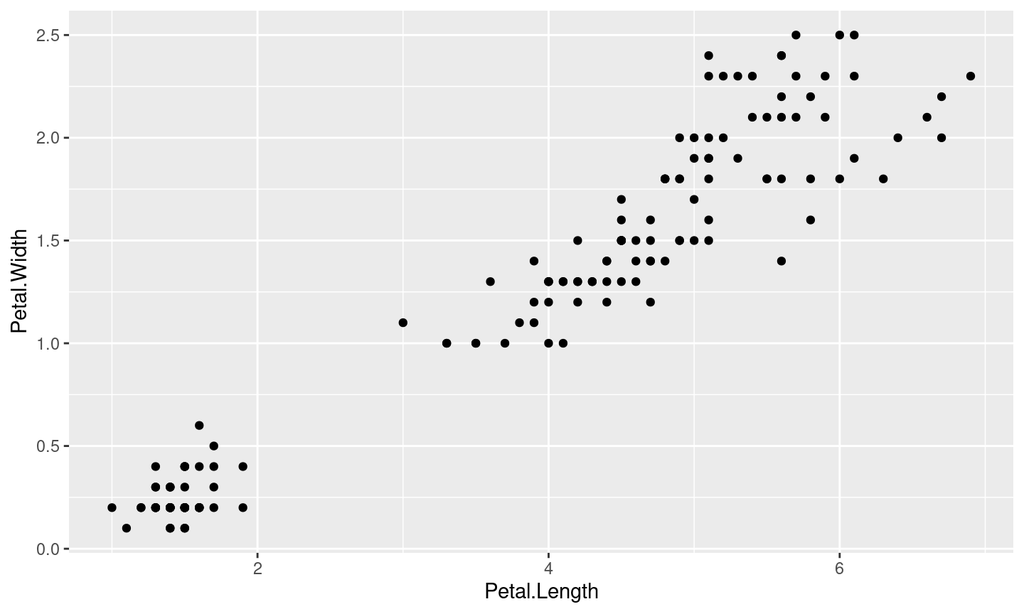

```r
iris %>% ggplot() + geom_point(aes(x = Petal.Length, y = Petal.Width))
```

Nosotros podemos seguir añadiendo capas para adecuar el grafico a nuestros requerimientos. Por ejemplo, podemos añadir una capa con una linea de tendencia y otra con rótulos.

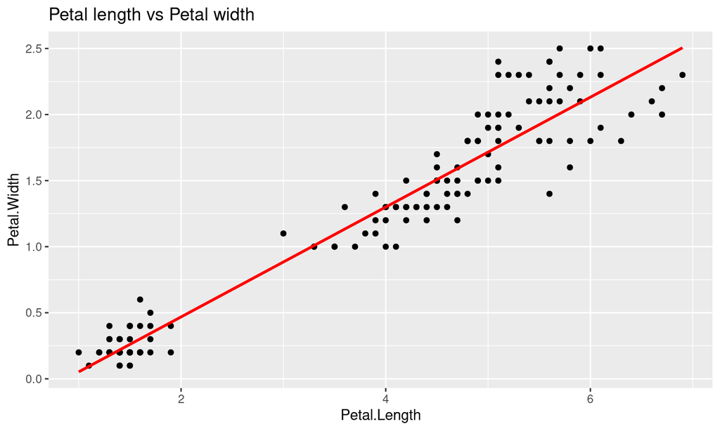

```r
iris %>% ggplot(aes(x = Petal.Length, y = Petal.Width)) + geom_point() + geom_smooth(method=lm , color="red", se=FALSE) +  ggtitle("Petal length vs Petal width")
```

### **Usar categorias como colores**

Tambien podemos coloear las observaciones usando un color especifico o usando los valores de alguna variable categorica.

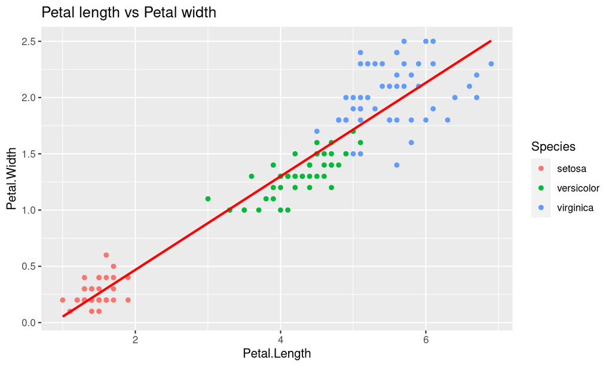

```r
iris %>% ggplot(aes(x = Petal.Length, y = Petal.Width, col=Species)) + geom_point() + geom_smooth(method=lm , color="red", se=FALSE) +  ggtitle("Petal length vs Petal width")
```

## Gráfico de dispersión

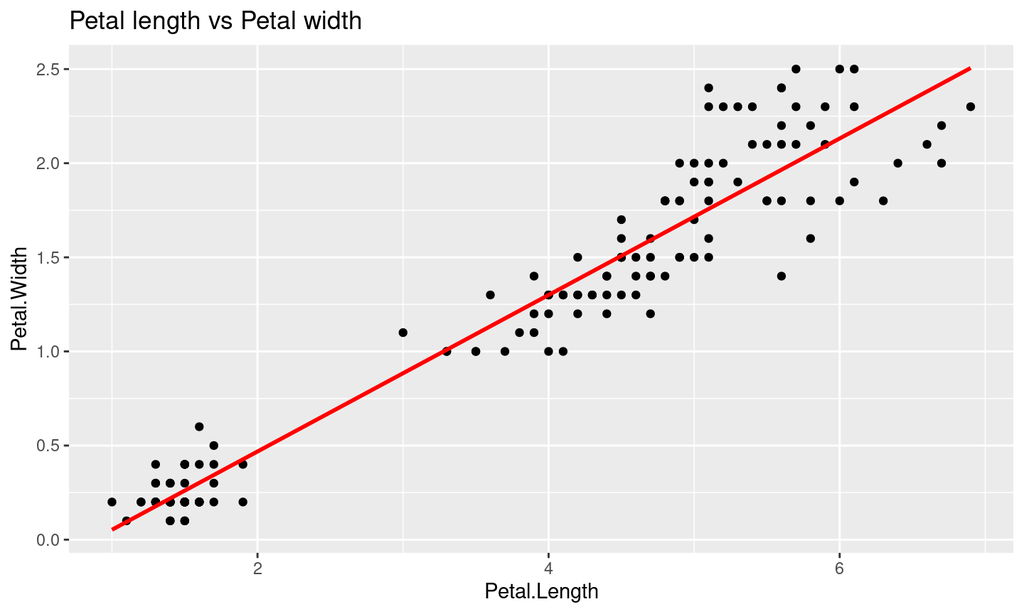

```r
iris %>%
  ggplot(aes(x = Petal.Length, y = Petal.Width)) +
  geom_point() + geom_smooth(method=lm , color="red", se=FALSE) +
  ggtitle("Petal length vs Petal width")
```

## Gráfico de Burbujas

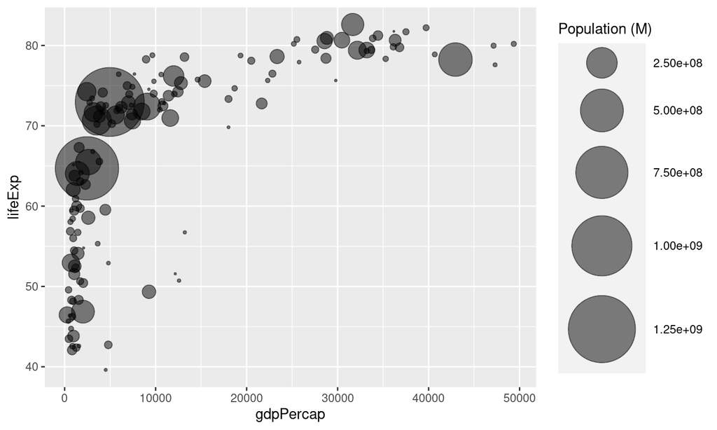

```r
# The dataset is provided in the gapminder library
library(gapminder)
data <- gapminder %>% filter(year=="2007") %>% dplyr::select(-year)

# Most basic bubble plot
data %>%
  arrange(desc(pop)) %>%
  mutate(country = factor(country, country)) %>%
  ggplot(aes(x=gdpPercap, y=lifeExp, size = pop)) +
    geom_point(alpha=0.5) +
    scale_size(range = c(.1, 24), name="Population (M)")
```

## Histograma

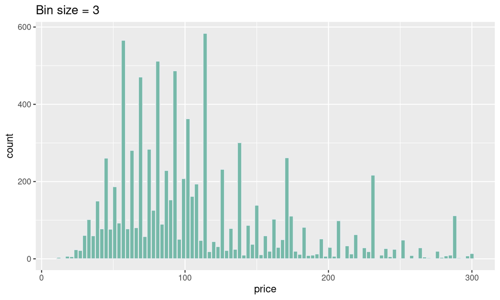

```r
# Load dataset from github
data <- read.table("https://raw.githubusercontent.com/holtzy/data_to_viz/master/Example_dataset/1_OneNum.csv", header=TRUE)

# plot
p <- data %>%
  filter( price<300 ) %>%
  ggplot( aes(x=price)) +
    geom_histogram( binwidth=3, fill="#69b3a2", color="#e9ecef", alpha=0.9) +
    ggtitle("Bin size = 3")
p
```

## Gráfico de barras

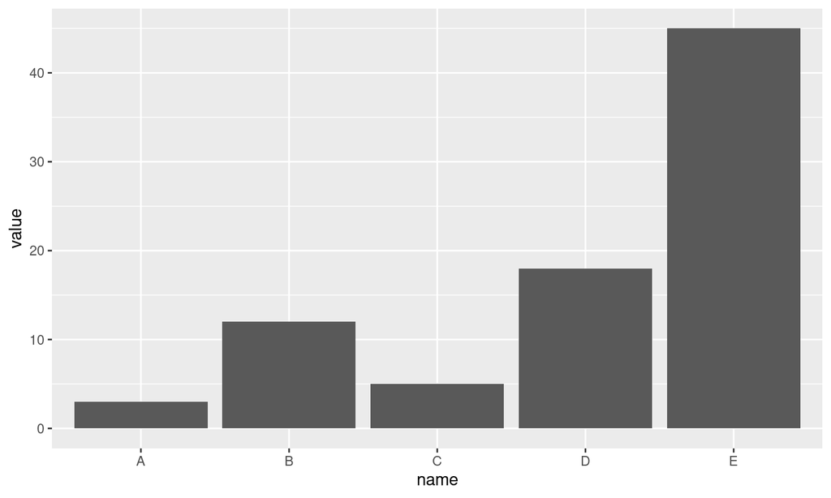

```r
# Create data
data <- data.frame(
  name=c("A","B","C","D","E") ,
  value=c(3,12,5,18,45)
  )

# Barplot
ggplot(data, aes(x=name, y=value)) +
  geom_bar(stat = "identity")
```

## Gráfico de Cajas y Bigotes

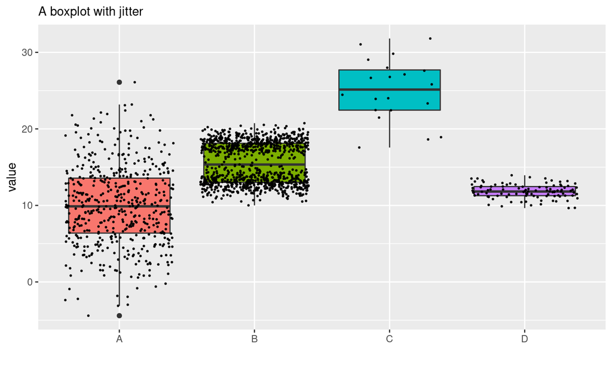

```r
# create a dataset
data <- data.frame(
  name=c( rep("A",500), rep("B",500), rep("B",500), rep("C",20), rep('D', 100)  ),
  value=c( rnorm(500, 10, 5), rnorm(500, 13, 1), rnorm(500, 18, 1), rnorm(20, 25, 4), rnorm(100, 12, 1) )
)

# Plot
data %>%
  ggplot( aes(x=name, y=value, fill=name)) +
    geom_boxplot() +
    geom_jitter(color="black", size=0.4, alpha=0.9) +
    theme(
      legend.position="none",
      plot.title = element_text(size=11)
    ) +
    ggtitle("A boxplot with jitter") +
    xlab("")
```

## Grafico de Mosaico

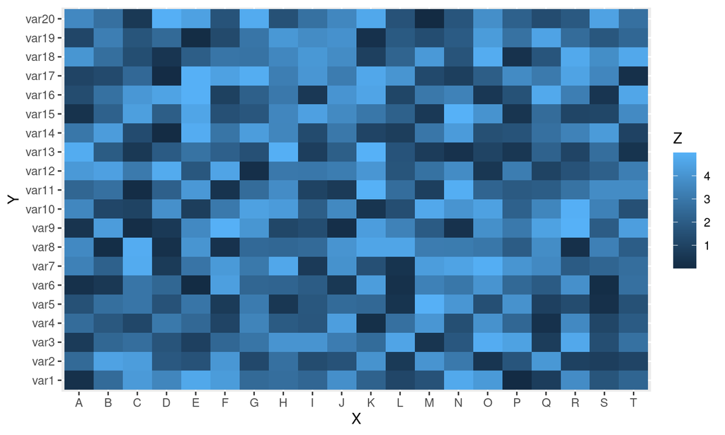

```r
# Dummy data
x <- LETTERS[1:20]
y <- paste0("var", seq(1,20))
data <- expand.grid(X=x, Y=y)
data$Z <- runif(400, 0, 5)

# Heatmap
ggplot(data, aes(X, Y, fill= Z)) +
  geom_tile()
```

## Animación (Bonus)

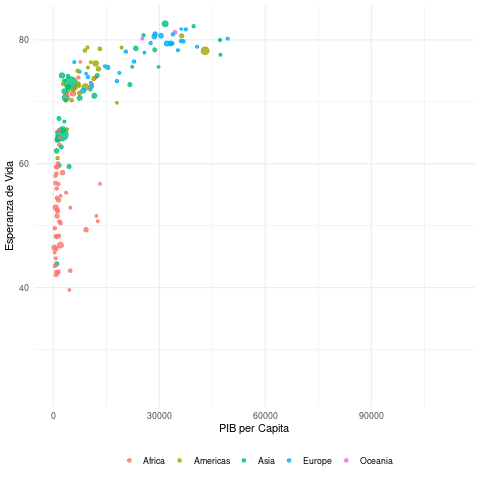

```r
library(gganimate)

datos = gapminder
grafico <- datos %>%
  ggplot() +
    geom_point(aes(x = gdpPercap, y = lifeExp, col = continent, size = pop), alpha = 0.8) + theme_minimal() +
    theme(legend.position = "bottom") + guides(size = "none") +
    labs(x = "PIB per Capita" ,y = "Esperanza de Vida",  col = "")

grafico +
  transition_time(year)
```